# Práctico N°1

## 0. Objetivo del práctico

El objetivo de este práctico es realizar un breve repaso a ciertos conceptos clave y definiciones básicas de los **fundamentos de probabilidad**, pasando por la definición de una variable, sus distribuciones, y las formas de medirlas y/o resumirlas.

Recordar que la idea principal que se encuentra a la base de la probabilidad refiere a que cuando observamos el comportamiento del azar, este resulta impredecible con pocas repeticiones pero presenta un **comportamiento regular y predecible** con muchas repeticiones.

### Materiales de la sesión

Recuerden que los archivos asociados a este práctico los pueden encontrar en: Apéndice A1 y B - Woolridge

## 1. Variables aleatorias y sus distribuciones de probabilidad

Las Variables Aleatorias (VA) son **variables estadísticas** en la que sus valores se obtienen a partir del resultado de algún tipo de experimento. En otras palabras, son variables cuyos valores son **resultados numéricos** de un fenómeno aleatorio. Un ejemplo de experimento puede ser algo tan simple como lanzar una moneda 20 veces y anotar las veces que obtenemos cara. La cantidad de veces que efectivamente salió cara en el experimento constituye una variable aleatoria. Este experimento puede ser realizado infinitas veces, y en otro ensayo se puede obtener un resultado completamente distinto.

Las variables aleatorias se dividen en *discretas* y *continuas*. Una **variable aleatoria discreta** es una variable que solo toma una cantidad finita o una cantidad infinita contable de valores. *¿Qué significa esto?* Significa que aunque la variable pueda tener resultados infinitos, estos solo toman valores enteros positivos. Por ejemplo, si lanzamos un dado y anotamos el resultado, solo podemos tener valores del 1 al 6. En ningún caso tendremos un resultado negativo o con decimales.

En ciertas ocasiones, estimaremos eventos que son cualitativos. Por ejemplo, nos interesa estimar la participación de los alumnos de enseñanza media en manifestaciones del estallido social. En ese caso, la variable también toma valores numéricos. Se puede definir la variable como: *X = 1* si se participa en la manifestación, *X = 0* si no se participa. En esta situación, como podrán notar, nos enfrentamos a una variable aleatoria discreta. Además, cuando una variable **solo** puede tomar los valores de 0 y 1, hablamos de una **variable binaria**.

Las variables aleatorias discretas se describen estadísticamente por su *distribución de probabilidad.* Esta corresponde a la probabilidad de la ocurrencia de cada valor de la variable. Siguiendo con el ejemplo del lanzamiento de un dado, su distribución de probabilidad consiste en todos los valores que puede tomar la variable (1 al 6) y la probabilidad de obtener cada una de ellas (en este caso, cada valor tiene una probabilidad de 1/6). La suma de la distribución de probabilidad es igual a 1.

Las variables aleatorias discretas se pueden representar en tablas o cuadros. Por ejemplo, si la variable corresponde a la cantidad de hijos:

**Tabla 1: Distribución de Probabilidad Variable Cantidad de Hijos**

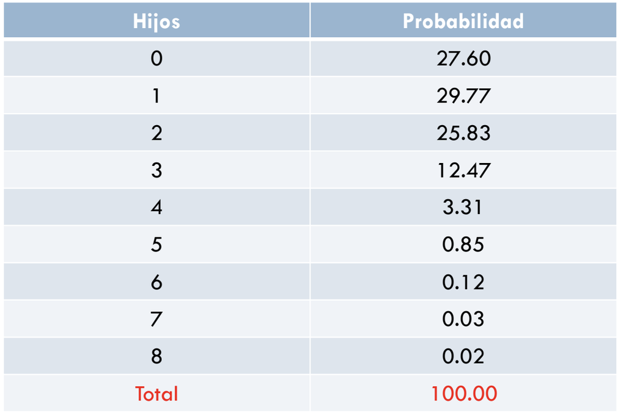

**Gráfico 1: Distribución de Probabilidad Variable Cantidad de Hijos (en porcentaje)**

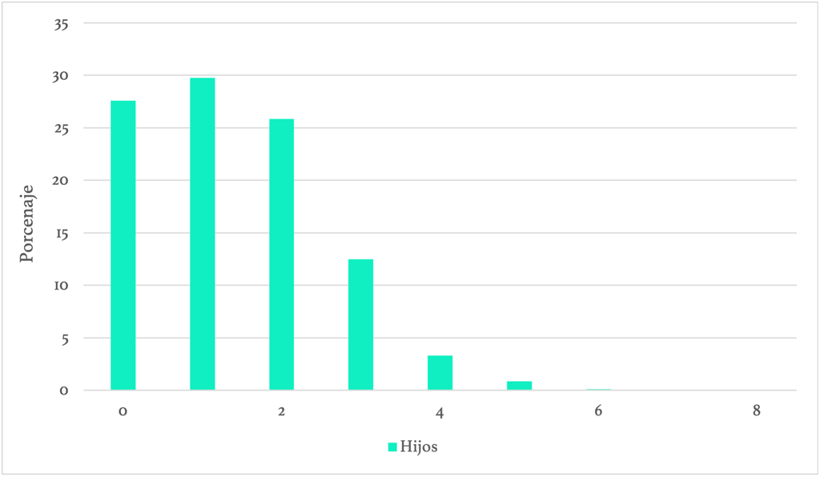

Al igual que la Distribución de Probabilidad, la Distribución de Probabilidad Acumulada (FDA) se puede representar en tablas o gráficos:

*Gráfico 2: Distribución de Probabilidad Acumulada (en porcentaje)*

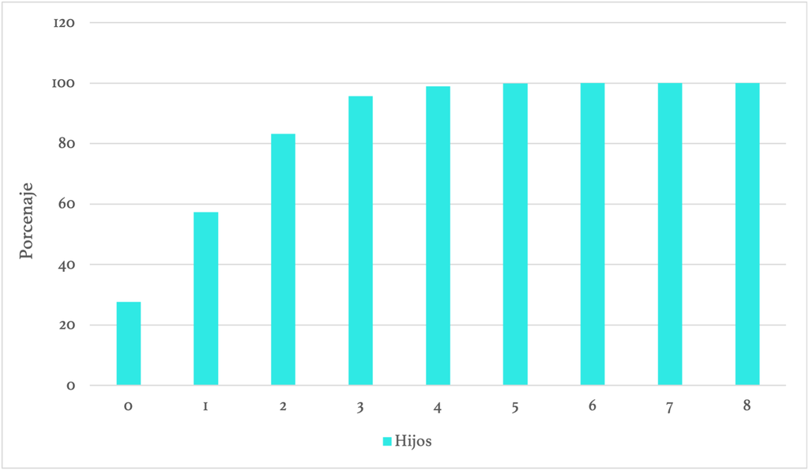

Las **VA continuas (VAC)** indican que $X$ puede tomar ciertos valores con probabilidad cero, es decir, una variable $X$ es una variable aleatoria continua si la probabilidad de que la variable aleatoria tome cualquier valor real sea igual a cero. Estas se describen por medio de su **función de densidad de probabilidad (fda)** de $X$ la cual resume la información concerniente a los valores que puede tomar $X$ y a sus correspondientes probabilidades. Si $X$ es cualquier variable aleatoria, entonces para cualquier número real *x* su fda está definida por:

$$F(x) \equiv P(X \leq x)$$

*Gráfico 3: Función de Densidad de Probabilidad*

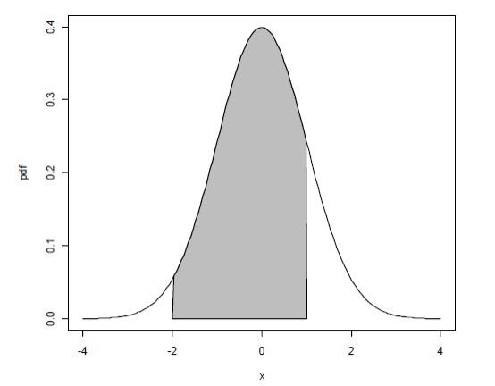

En este gráfico podemos observar que:

$$Pr(-2\leq X \leq 1)$$

se encuentra representada por el área debajo de la curva. Para todas las distribuciones continuas importantes en la probabilidad y en la estadística, las funciones de distribución acumulada ya han sido tabuladas, y la más conocida de estas es la **distribución normal.**

## 2. Distribuciones conjuntas, condicionales, marginales e independencia

### 2.1 Distribución Conjunta

En muchos casos, resulta interesante estudiar de manera conjunta el comportamiento de las variables. En dichos caso, se construye lo que se denomina **distribución conjunta**. Su objetivo consiste en determinar cómo la variación de una variable se relaciona con la de otra. En el caso de que $(X,Y)$ sean variables aleatorias discretas, entonces $(X,Y)$ tienen una distribución conjunta, descrita completamente por la **función de densidad de probabilidad conjunta** de $(X,Y)$

*Tabla 3: Distribución Conjunta del Gasto en Vestimenta*

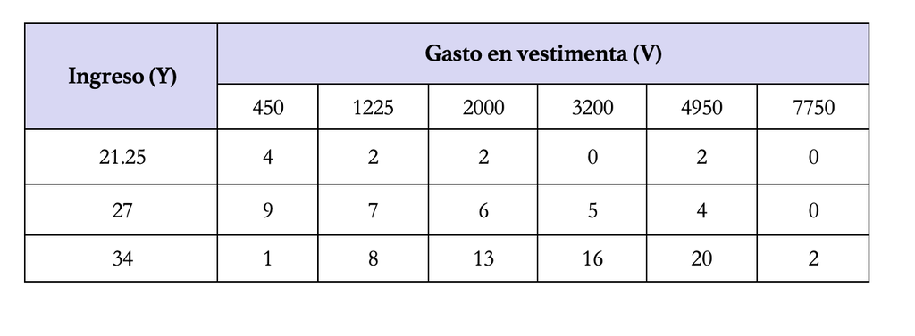

¿Distribución del gasto para cualquier nivel de ingreso? o ¿Distribución del gasto para cada nivel de ingreso?

*Tabla 4: Distribución Marginal del Gasto en Vestimenta*

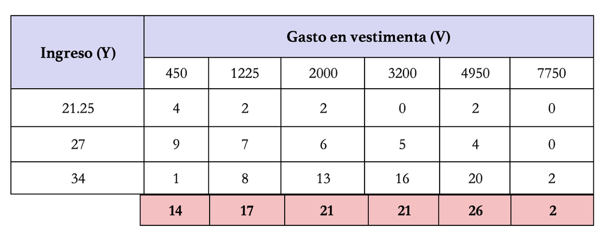

Las casillas en color rosado nos muestra la distribución marginal del gasto en vestimenta.

### 2.2 Distribución Marginal

Las distribuciones de la variable fila y de la variable columna, de forma separada, se llaman **distribuciones marginales**, ya que aparecen en los márgenes derecho e inferior de la tabla de contingencia. La columna de totales y la fila de totales de una tabla de contingencia dan las distribuciones marginales de las dos variables de forma separada. **Las distribuciones marginales no dan información sobre la relación entre las variables.**

Cada componente de una variable aleatoria bidimensional es una variable aleatoria unidimensional en sí misma. Es por esto que nos puede interesar conocer la distribución de un componente por separado, sin tener en cuenta el otro componente. Eso se denomina marginar, y la **distribución de la variable unidimensional** por separado se llama distribución marginal.

La **distribución marginal** del gasto en vestimenta equivale a su **distribución unidimensional**:

*Tabla 5: Distribución Marginal del Gasto en Vestimenta*

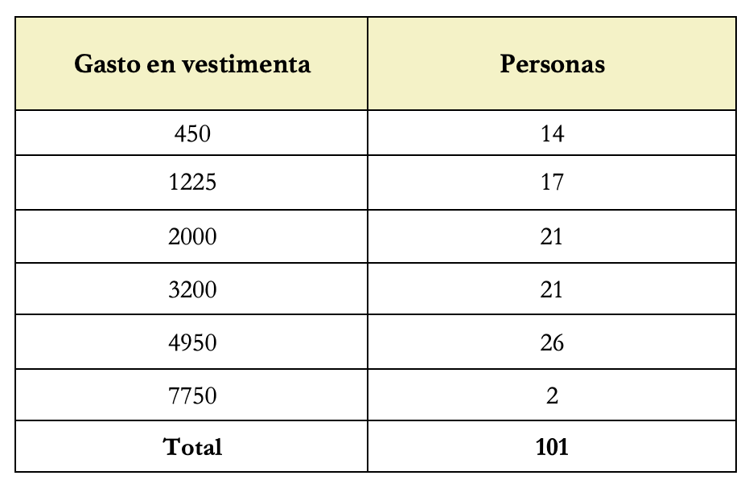

La **media** es de 2777.5 y la **desviación estándar** es de 1739.

### 2.3 Distribución Condicional

Para hallar la **distribución condicional** de la variable fila con relación a un valor determinado de la variable columna, fíjate sólo en esa columna de la tabla. Expresa cada valor de la columna como un porcentaje del total de la columna. Existe una distribución condicional de la variable fila para cada columna de la tabla. La comparación de estas distribuciones condicionales es una manera de mostrar la asociación entre la variable fila y la variable columna. Es especialmente útil cuando la variable columna es la variable explicativa.

*Tabla 6: Distribución Condicional del Gasto en Vestimenta*

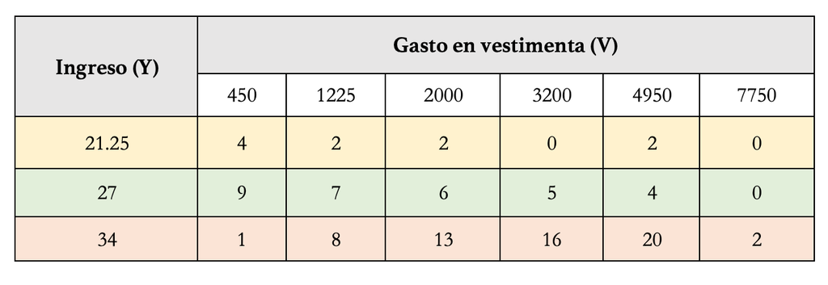

La media condicional para la fila amarilla es de 1815, para la fila verde de 1949.2 y para la fila roja es de 3365.8.

### 2.4. Media condicional

*Tabla 7: Media y media condicional*

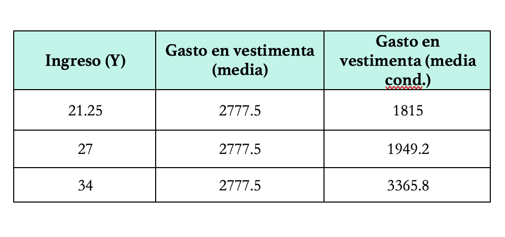

Ventaja: aprovechar la información contenida en la variable ingreso.

### 2.5. Independencia

Formalmente,

$$Pr(Y=y|X=x)=Pr(Y=y)$$

Su implicancia es:

$$Pr(X=x,Y=y)=Pr(X=x)*Pr(Y=y)$$

## 3. Características de las distribuciones de probabilidad

### 3.2 Medidas de tendencia central: Mediana

En general, es la puntuación que se encuentra en la mitad de una distribución de puntuaciones x. Indica el valor bajo el cual se encuentra el 50% de los casos. Su cálculo sólo exige orden en las puntuaciones, se puede aplicar a variables de escalares y ordinales. Es el **valor** que se ubica en la **mitad** de la distribución de los datos.

### 3.3 Medidas de tendencia central: Moda

El **atributo** que más se repite o posee **mayor frecuencia** en una muestra.

### 3.5 Medidas de Variabilidad o Dispersión: Desviación Estándar

La **desviación estándar** de una variable aleatoria, que se denota sd($$X$$), es la raíz cuadrada positiva de la varianza:

$$sd(X) \equiv + \sqrt{Var(X)}$$

La desviación estándar también se suele expresar así: $$σ$$.

## 4. Características de las distribuciones conjuntas y de las condicionales

### 4.1 Covarianza

Formalmente,

$$cov(X,Y)=E[(X-\mu_x)(Y-\mu_y)]= \sigma_{xy}$$

Su interpretación es la siguiente:

- Si
  $$X$$
  tiende a ser mayor que su media cuando Y está por encima de su media y viceversa, entonces la covarianza entre
  $$X$$
  e
  $$Y$$
  es positiva.
- Por el contrario, si se mueven en direcciones opuestas, la covarianza es negativa.
- Si
  $$X$$
  e $$Y$$ son independientes, entonces la covarianza es cero.

### 4.2 Correlación

La covarianza es difícil de interpretar debido al “problema de las unidades de medida”. La correlación es una **medida alternativa** que resuelve este problema.

La **correlación** mide la fuerza y la dirección de la relación lineal entre dos variables cuantitativas. La correlación se simboliza con la letra
$$r$$
.

Formalmente,

donde

$$-1\leq corr(X,Y) \leq1$$

*Gráfico 5: Tipos de correlaciones*

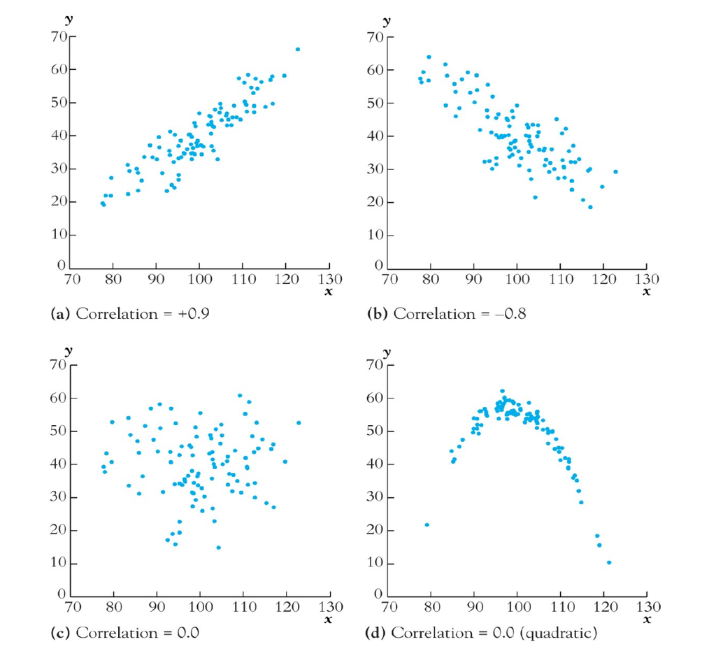

## 5. Resumen

En este práctico realizamos un repaso de algunos **conceptos claves** que son fundamentales estadística básica e inferencial aplicada a la probabilidad, estos se centraron en:

1. Distribución Conjunta, Marginal, y Condicional
2. Independencia
3. Covarianza y Correlación